# Simulating and interpreting SIR dynamics

Shadrach Mintah

In this walk through, we will be simulating an SIR model.

The SIR model is a simple compartmental model used to describe the spread of MPOX, which is an infectious disease in a population. The model divides the population into three compartments: susceptible (S), infectious (I), and recovered (R) individuals. The model equations describe the flow of individuals between these compartments based on the transmission rate ($\beta$) and the recovery rate ($\gamma$).

## The model function

We start by defining the model equations.

The SIR model equations is given by:

$$\begin{align}
\frac{dS}{dt} & = \color{orange}{\frac{-\beta S I}{N}} \\
\frac{dI}{dt} & = \color{orange}{\frac{\beta S I}{N}} -
\color{blue}{\gamma I} \\
\frac{dR}{dt} & = \color{blue}{\frac{\gamma I}{N}}
\end{align}$$

but

- $\beta$ = (b1 + b2 + b3)
- $\gamma$ = (y1 +y2)

where:

- $N$ is the population
- $S$ is the number of susceptible individuals,
- $I$ is the number of infectious individuals,
- $R$ is the number of removal individuals,
- $\beta$ is the transmission rate,
- $\gamma$ is the removal rate.
- $b1$ is the rate of transmission by sexual contact
- $b2$ is the rate of transmission by direct contact
- $b3$ is the rate of transmission by airborne
- $y1$ is the rate of removal due to mortality of other cause and migration
- $y2$ is the rate of removal due to recovered or died of MPOX

which translates into:

$$\begin{align}
\frac{dS}{dt} & = \color{orange}{-(b1 + b2 + b3) \frac{S I}{N}} \\
\frac{dI}{dt} & = \color{orange}{(b1 + b2 + b3) \frac{S I}{N}} -
\color{blue}{(y1 + y2) I} \\
\frac{dR}{dt} & = \color{blue}{\frac{(y1 + y2) I}{N}}
\end{align}$$

where: - $N$ is the population - $S$ is the number of susceptible individuals, - $I$ is the number of infectious individuals, - $R$ is the number of removal individuals, - $\beta$ is the transmission rate, - $\gamma$ is the recovery rate.

- We use the `with()` function to evaluate the expressions in the context of the list created by `as.list(c(state, parameters))`. This allows us to access the state variables and parameters directly without having to use the `$` operator. This makes the code easier to read and write (Run `?with` in the R console and read the documentation of the first three arguments).
- The function returns a list of the derivatives of the state variables. This is the format expected by the `lsoda()` function (Run `?deSolve::lsoda` in the R console and read the documentation of the first three arguments).

## Model parameters

Next, we will define the parameter values and initial conditions.

The model has two parameters: $\beta$ and $\gamma$.

$\beta$ is a composite of different terms and is not intuitive at face value, so we will define it in terms of the basic reproduction number ($R0$) and the infectious period using the relation $R0 = \frac{\beta}{\gamma}$.

## Initial conditions

Due to numerical stability issues, we will specify the populations as proportions and assume they sum up to $1$. We will then scale the populations to the actual population size after obtaining the results.

We will assume the outbreak starts with $0.01$ infectious individual at the start of the simulation. The population is completely susceptible at the start of the simulation, so the number of susceptible individuals is $N - 0.01$. The number of recovered individuals is zero at the start of the simulation.

## Time steps to return results

`lsoda()` also expects a vector of time points at which to return results. We will run the model for 365 days and return results at each day.

## Solving the model

Now, we are ready to solve the model. We will solve the model using the `lsoda()` function from the `{deSolve}` package. For now, we will use the default values of the function. You are encouraged to explore the documentation to understand the function better.

The results are stored in a matrix with the first column representing the time points and the subsequent columns representing the number of individuals in the susceptible, infectious, and recovered compartments at each time point.

To work with the results more easily, we will convert the results to a data frame.

```
##   time         S          I            R
## 1    1 0.9900000 0.01000000 0.0000000000
## 2    2 0.9885356 0.01072423 0.0007401503
## 3    3 0.9869678 0.01149840 0.0015338130
## 4    4 0.9852897 0.01232560 0.0023846669
## 5    5 0.9834953 0.01320861 0.0032961105
## 6    6 0.9815758 0.01415127 0.0042728941
```

### Plotting the results

Now, let’s plot the results.

We will use the `ggplot2` package to plot the results. We will reshape the data to long format to make it easier to plot. For this, we will use the `pivot_longer()` function from the `tidyr` package.

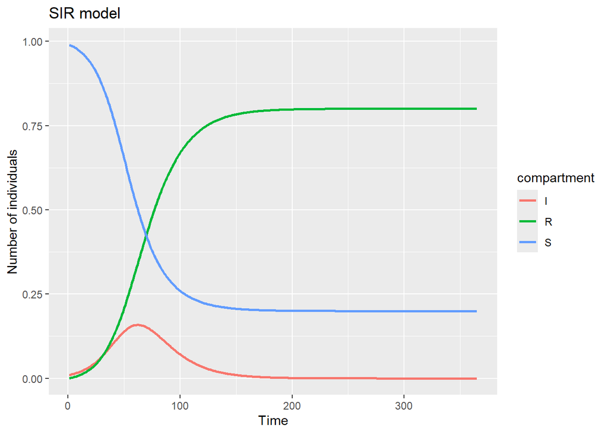

```
##   time         S          I            R
## 1    1 0.9900000 0.01000000 0.0000000000
## 2    2 0.9877237 0.01150900 0.0007673491
## 3    3 0.9851118 0.01323825 0.0016499781
## 4    4 0.9821182 0.01521735 0.0026644625
## 5    5 0.9786885 0.01748094 0.0038305649
## 6    6 0.9747649 0.02006546 0.0051696213
```

## R0 = c(1, 2, 3, 4, 5)

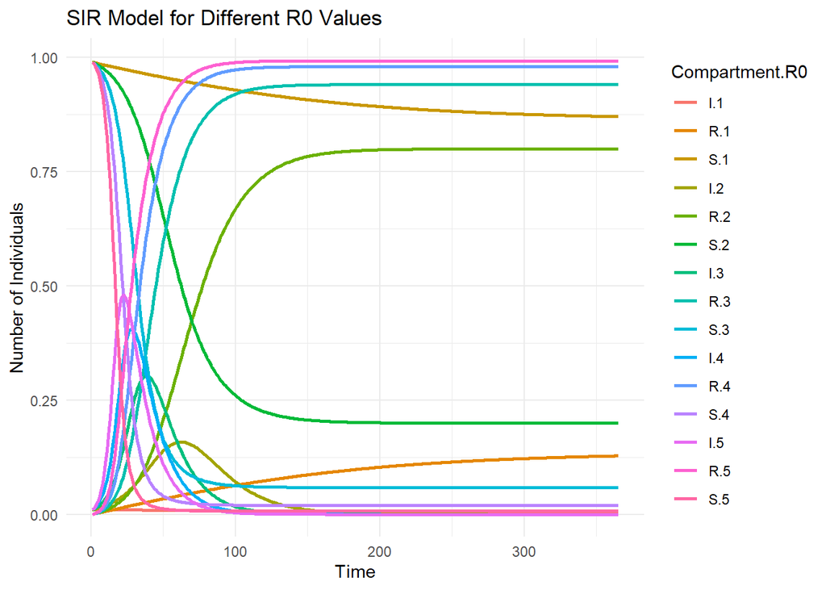

```
##   time         S          I           R
## 1    1 0.9900000 0.01000000 0.000000000
## 2    2 0.9822300 0.01383022 0.003939827
## 3    3 0.9716187 0.01901031 0.009370976
## 4    4 0.9572788 0.02591560 0.016805646
## 5    5 0.9381779 0.03493865 0.026883431
## 6    6 0.9132096 0.04641939 0.040371000
```

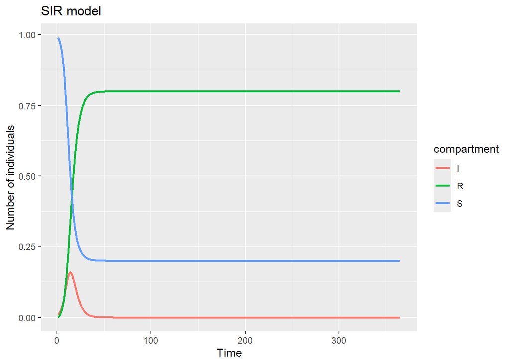

```
##   time         S          I           R
## 1    1 0.9900000 0.01000000 0.000000000
## 2    2 0.9879212 0.01102777 0.001051038
## 3    3 0.9856343 0.01215587 0.002209855
## 4    4 0.9831212 0.01339248 0.003486361
## 5    5 0.9803607 0.01474702 0.004892254
## 6    6 0.9773307 0.01622927 0.006440007
```

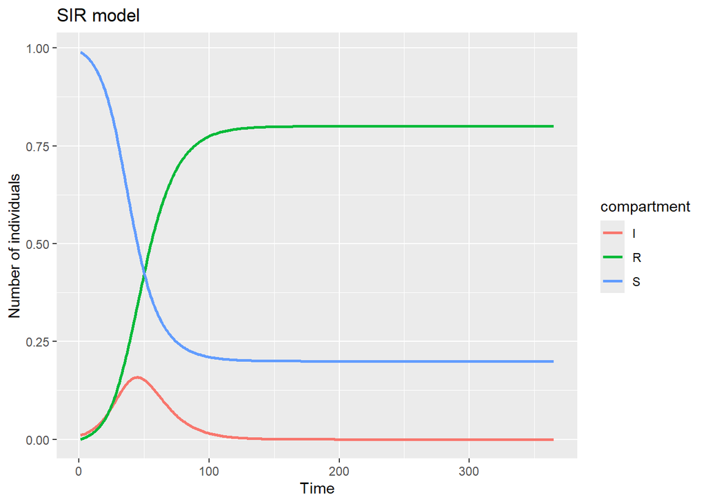

```
##   time         S          I           R
## 1    1 0.9900000 0.01000000 0.000000000
## 2    2 0.9859229 0.01325175 0.000825377
## 3    3 0.9805528 0.01752945 0.001917710
## 4    4 0.9735006 0.02313807 0.003361379
## 5    5 0.9642842 0.03045196 0.005263888
## 6    6 0.9523101 0.03992691 0.007762999
```

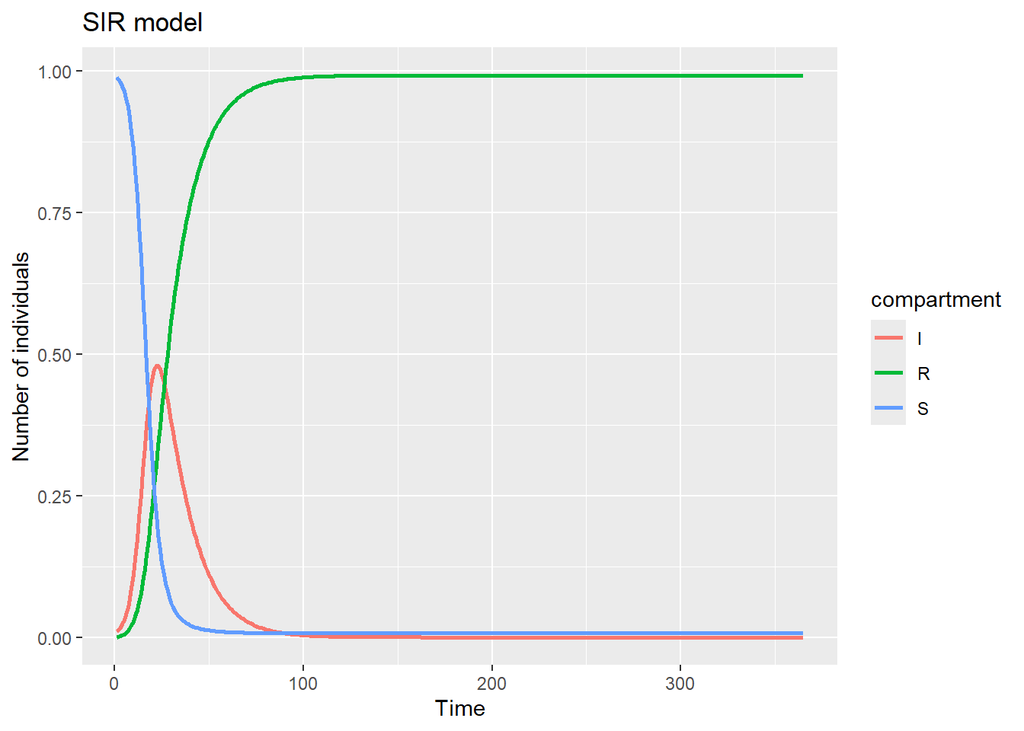

```
##   time         S           I            R
## 1    1 0.9900000 0.010000000 0.0000000000
## 2    2 0.9892934 0.009992608 0.0007140217
## 3    3 0.9885878 0.009984717 0.0014274976
## 4    4 0.9878833 0.009976330 0.0021403921
## 5    5 0.9871799 0.009967449 0.0028526744
## 6    6 0.9864776 0.009958076 0.0035643032
```

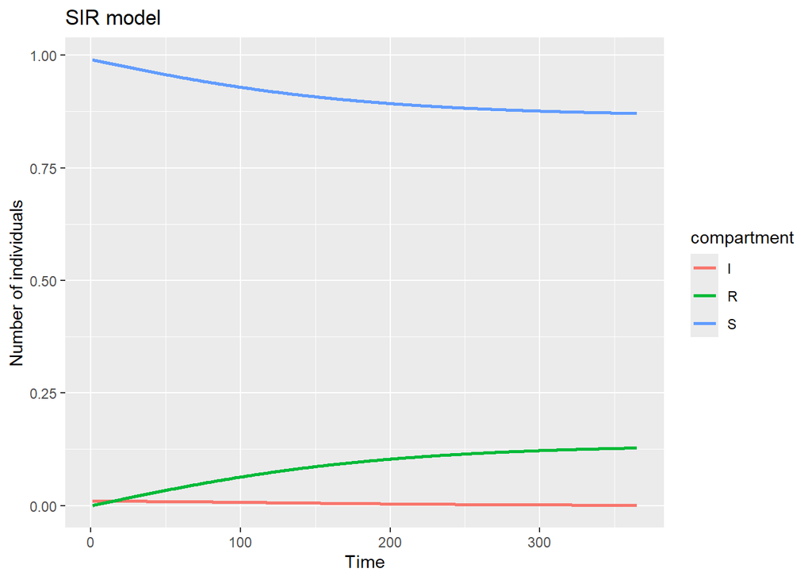

## Exercise

Answer the following questions by adding code chunks and text chunks.

1. What do you observe from the plot above? Can you describe the dynamics of the SIR model?

   **At day 1, All in the population was susceptible to the disease, 1 possibly infected person, and no recovered person in the population. As the number of infected started to increase, the susceptible was reducing and the recovered also started increasing. At aroung day 70, the infection time reached a peak and began to fall. Those with the disease mostly recovered after day 100, with 20% of the population not getting the disease. After day 150, the in disease was no spreading more in the population**
2. Change the value of the basic reproduction number ($R0$) to 3 and observe the effect on the dynamics of the SIR model.

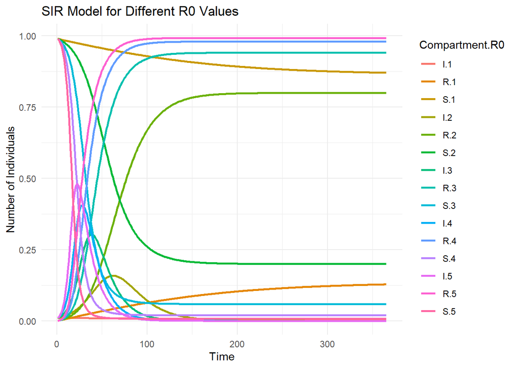

4. Change the value of the infectious period to 3 and 10 days and observe the effect on the dynamics of infection. ** Infectious days = 3, R0=2

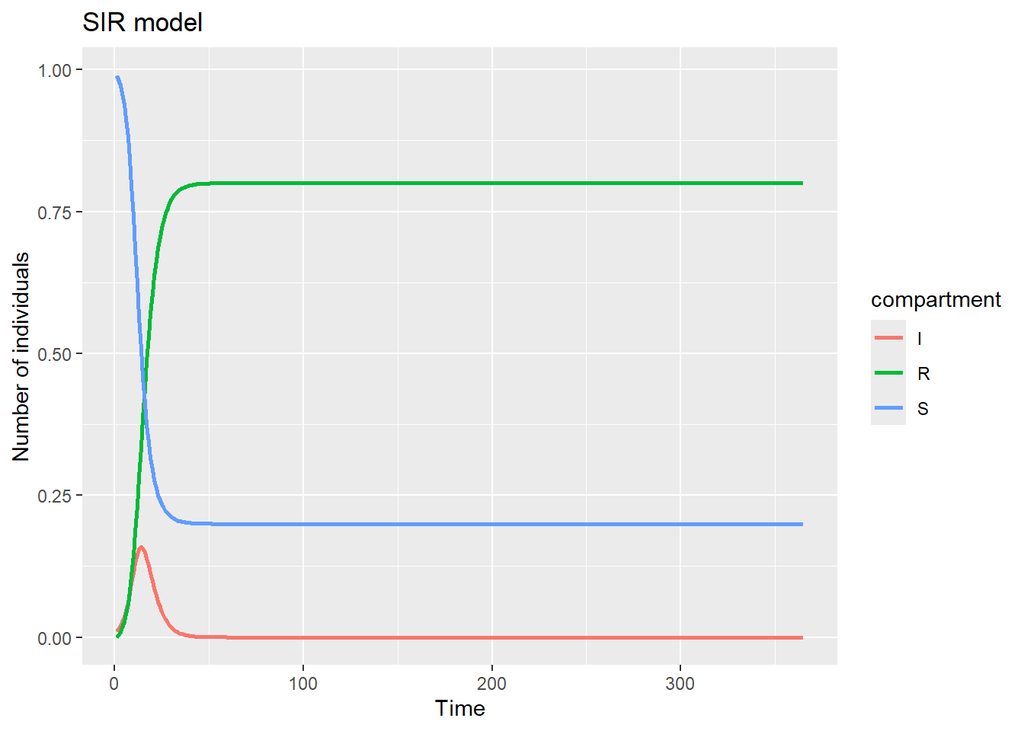

   infectious days = 10, R0=2 **

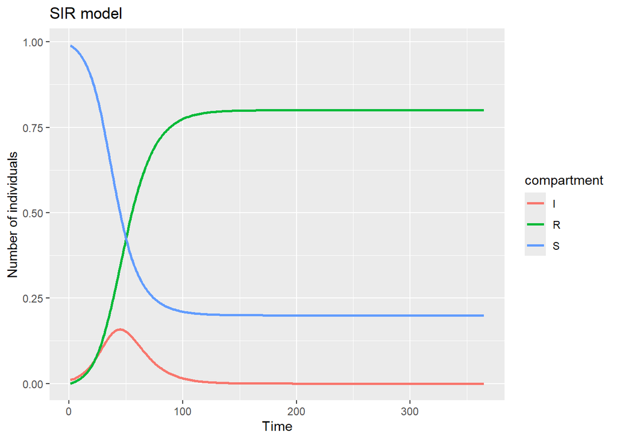

5. What are the features of a disease that dies out quickly assuming $R0 > 1$? ** Infectious days = 14, r0 = 5 **

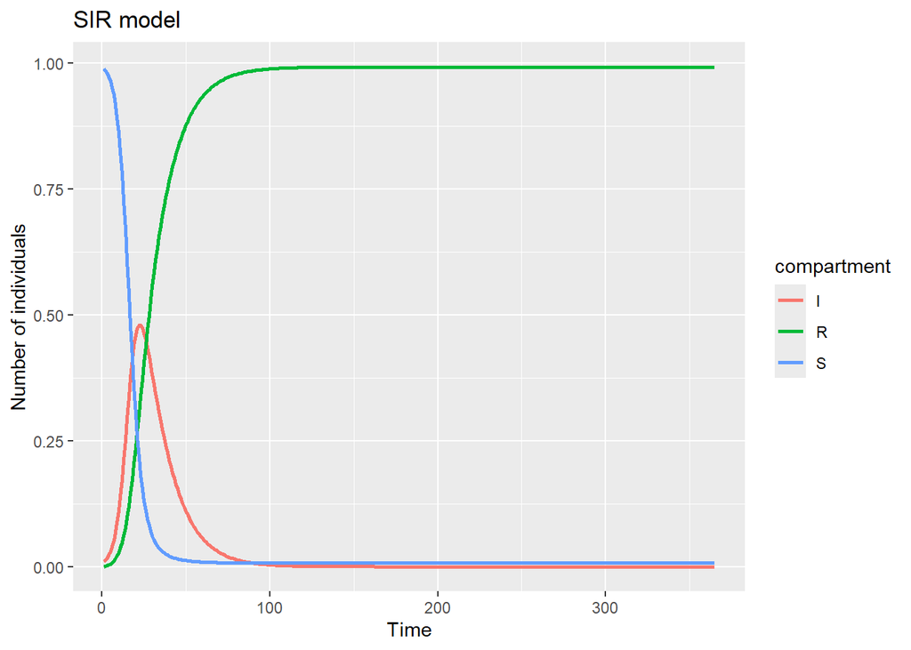

** Infectious days = 14, r0 = 1 **

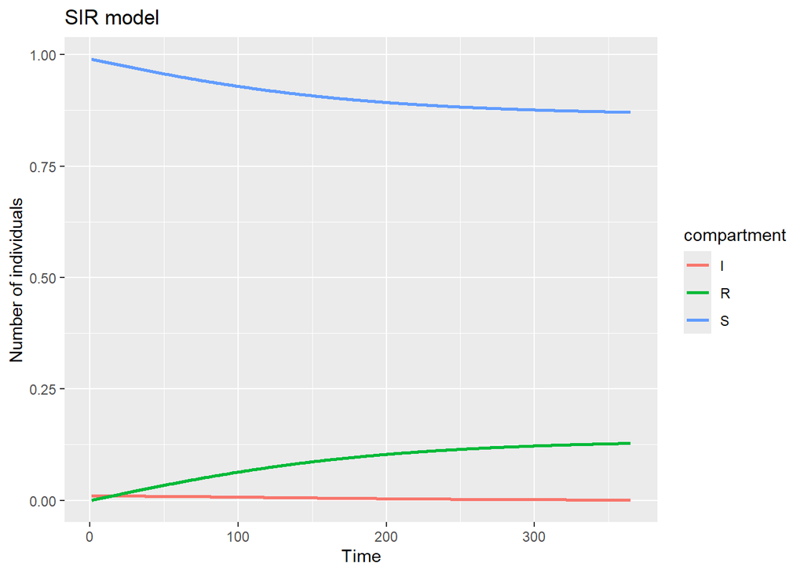